# Capítulo 4

#### **Figura 1.** Esquematização do modelo SIR

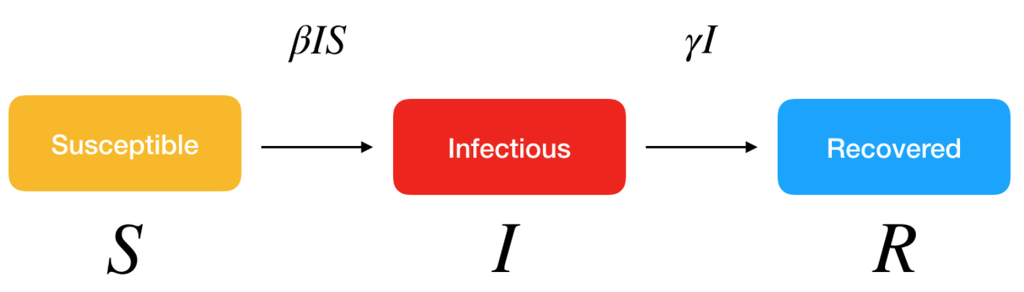

$$ \\ \\ \\ \\ $$ Para resolver o sistema (9), devemos, primeiro, determinar algumas condições iniciais. A primeira delas, é o número de infectados no tempo inicial, bem como o número de recuperados. Devemos, também, apresentar a população total local e, de posse desses valores, podemos obter o valor de invidíduos suscetíveis utilizando a equação (5). Devemos, também, determinar a taxa de recuperação da doença e a taxa de contágio dela. $$ \\ $$ Consideremos, então, que uma epidemia deseja ser modelada para uma determinada cidade, sendo que a população total dessa cidade é de 100.000 habitantes. Em determinado momento, as autoridades sanitárias percebem que uma nova doença surgiu na cidade, apresentando número de infectados igual a 100 e número de recuperados igual a 30. Deseja-se saber a curva de crescimento de infectados, de recuperados e a curva de pessoas suscetíveis à doença para o períogo de 3 meses. Considere a taxa de contágio igual a 0,5 e a taxa de recuperação da doença igual a 0,3.

```python
def modelo_SIR(y, t, beta, gamma, N):

    s, i, r = y

    dSdt = -beta * s * i / N
    dIdt = beta * s * i / N - gamma * i
    dRdt = gamma * i

    return [dSdt, dIdt, dRdt]

def estimativa(beta, gamma, N, i0, r0, tempo):

    s0 = N - i0 - r0
    y_0 = [s0, i0, r0]
    sol = odeint(modelo_SIR, y_0, tempo, args=(beta, gamma, N))

    sol = np.transpose(sol)

    return sol

def plot(t, S, I, R):

    fig = plt.figure(figsize=(14,10), facecolor='w')
    ax = fig.add_subplot(111, facecolor='#dddddd', axisbelow=True)
    ax.plot(t, S, 'b', alpha=0.5, lw=2, label='Suscetíveis')
    ax.plot(t, I, 'r', alpha=0.5, lw=2, label='Infectados')
    ax.plot(t, R, 'g', alpha=0.5, lw=2, label='Recuperados')

    ax.set_xlabel('Tempo (dias)')
    ax.set_ylabel('Número de indivíduos')
    ax.yaxis.set_tick_params(length=0)
    ax.xaxis.set_tick_params(length=0)
    ax.grid(b=True, which='major', c='w', lw=2, ls='-')

    legend = ax.legend(loc='center right', fontsize=15, bbox_to_anchor=(1.2, 0.5))

    for spine in ('top', 'right', 'bottom', 'left'):
        ax.spines[spine].set_visible(False)

    plt.show()
```

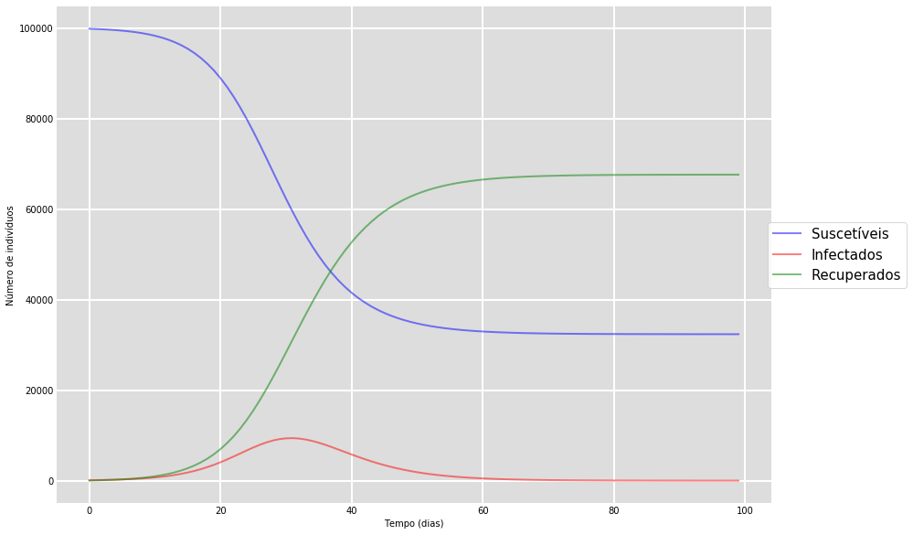

```python
t = np.arange(0,100,1)

beta = 0.5
gamma = 0.3

i0 = 100
r0 = 30

N = 100000

S, I, R = estimativa(beta, gamma, N, i0, r0, t)

plot(t, S, I, R)
```

Agora, vejamos o que acontece se variarmos algumas dessas características da transmissão da doença, variando a taxa de contágio, a taxa de recuperação e a população infectada inicialmente.

```
 ################################

População:  100000
Recuperados inicialmente:  30
Infectados inicialmente:  50
Taxa de contágio:  0.2
Taxa de recuperação:  0.1

 ################################
```

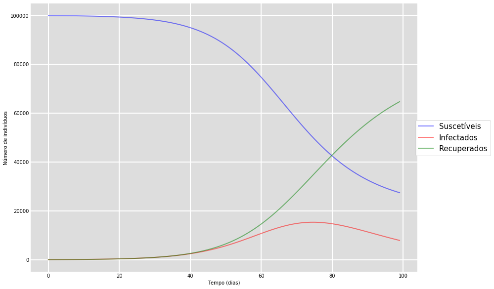

```
 ################################

População:  100000
Recuperados inicialmente:  30
Infectados inicialmente:  100
Taxa de contágio:  0.2
Taxa de recuperação:  0.1

 ################################
```

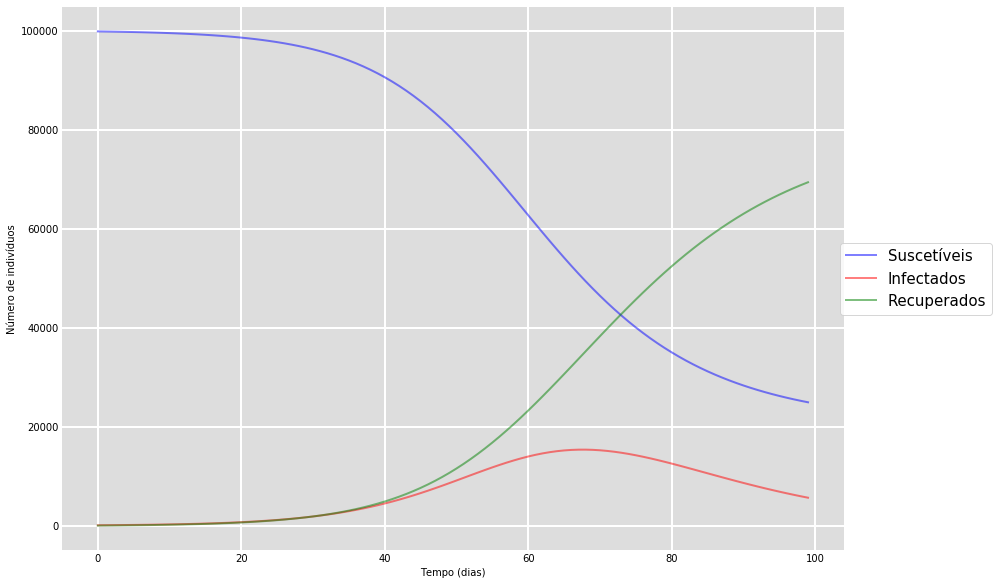

```
 ################################

População:  100000
Recuperados inicialmente:  30
Infectados inicialmente:  200
Taxa de contágio:  0.2
Taxa de recuperação:  0.1

 ################################
```

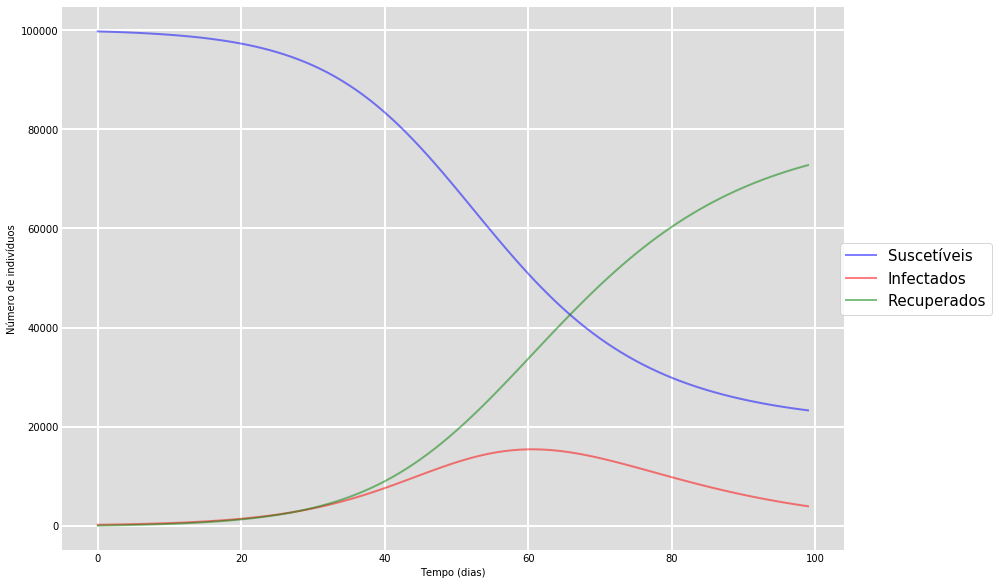

```
 ################################

População:  100000
Recuperados inicialmente:  30
Infectados inicialmente:  50
Taxa de contágio:  0.2
Taxa de recuperação:  0.3

 ################################
```

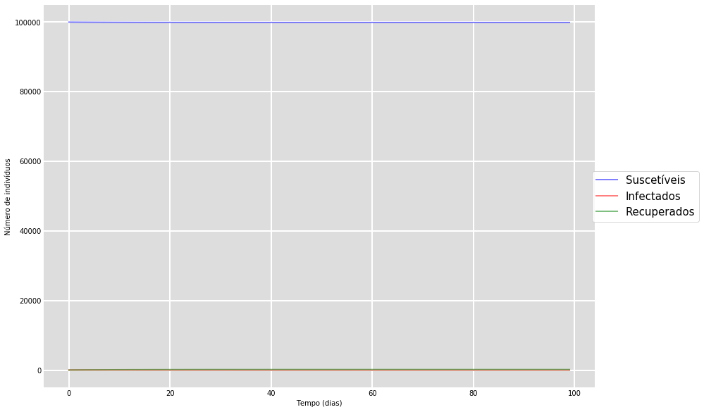

```
 ################################

População:  100000
Recuperados inicialmente:  30
Infectados inicialmente:  100
Taxa de contágio:  0.2
Taxa de recuperação:  0.3

 ################################
```

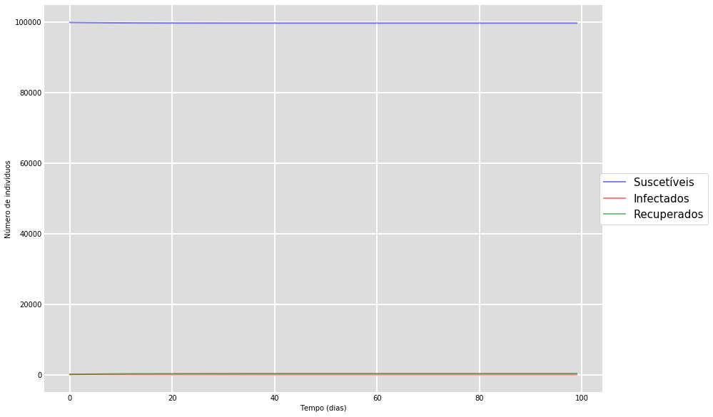

```
 ################################

População:  100000
Recuperados inicialmente:  30
Infectados inicialmente:  200
Taxa de contágio:  0.2
Taxa de recuperação:  0.3

 ################################
```

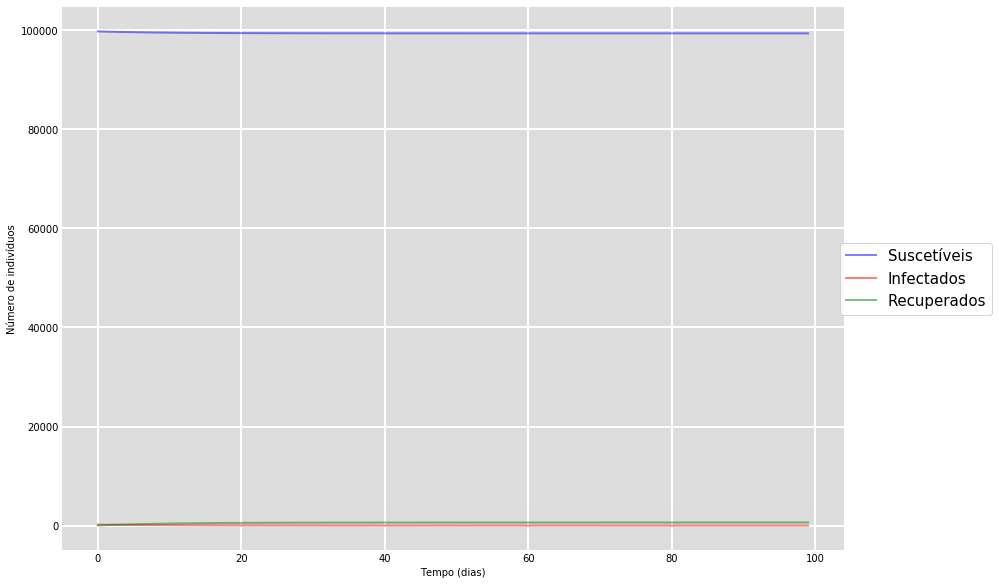

```
 ################################

População:  100000
Recuperados inicialmente:  30
Infectados inicialmente:  50
Taxa de contágio:  0.2
Taxa de recuperação:  0.5

 ################################
```

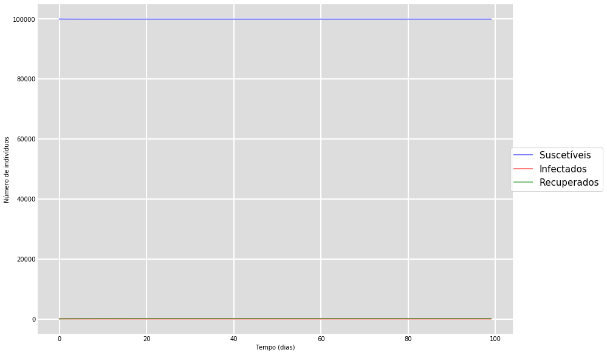

```
 ################################

População:  100000
Recuperados inicialmente:  30
Infectados inicialmente:  100
Taxa de contágio:  0.2
Taxa de recuperação:  0.5

 ################################
```

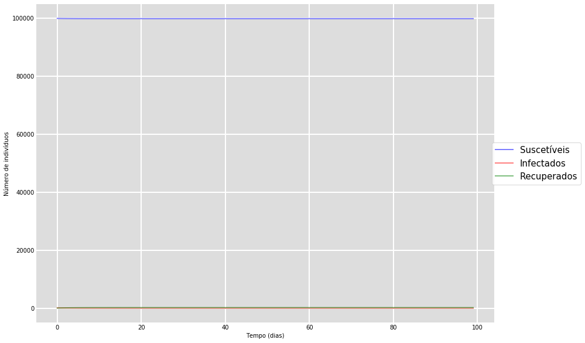

```
 ################################

População:  100000
Recuperados inicialmente:  30
Infectados inicialmente:  200
Taxa de contágio:  0.2
Taxa de recuperação:  0.5

 ################################
```

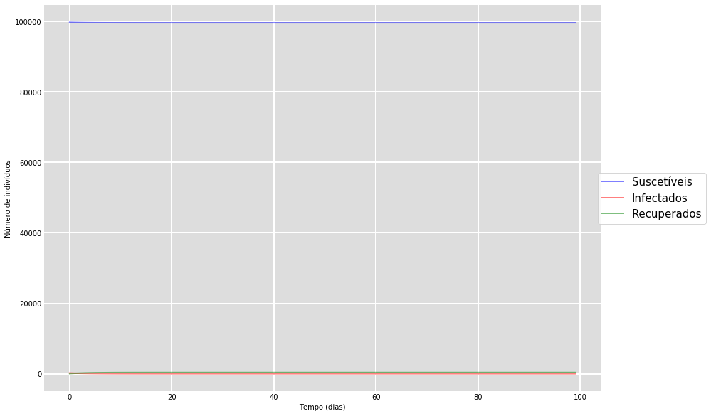

```
 ################################

População:  100000
Recuperados inicialmente:  30
Infectados inicialmente:  50
Taxa de contágio:  0.4
Taxa de recuperação:  0.1

 ################################
```

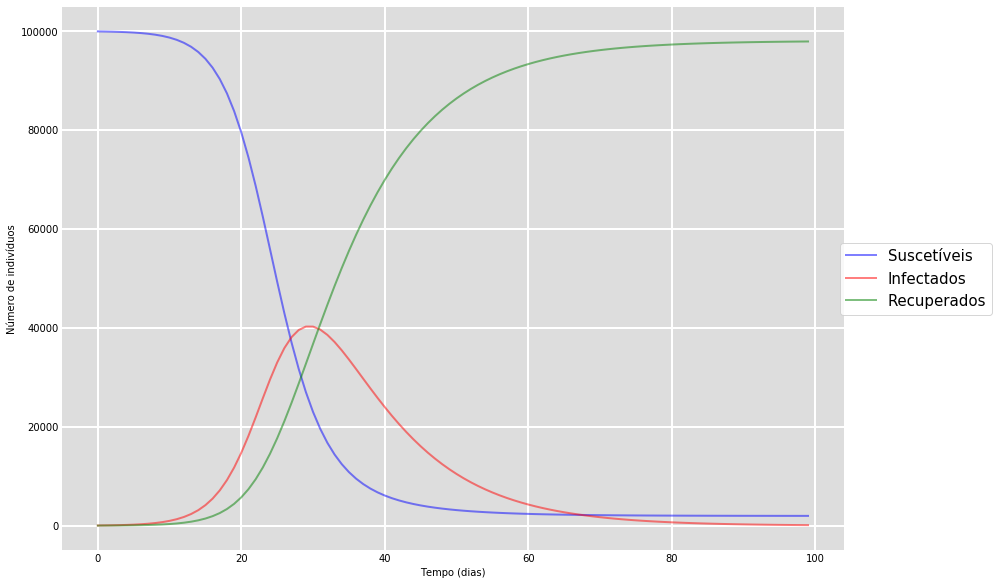

```
 ################################

População:  100000
Recuperados inicialmente:  30
Infectados inicialmente:  100
Taxa de contágio:  0.4
Taxa de recuperação:  0.1

 ################################
```

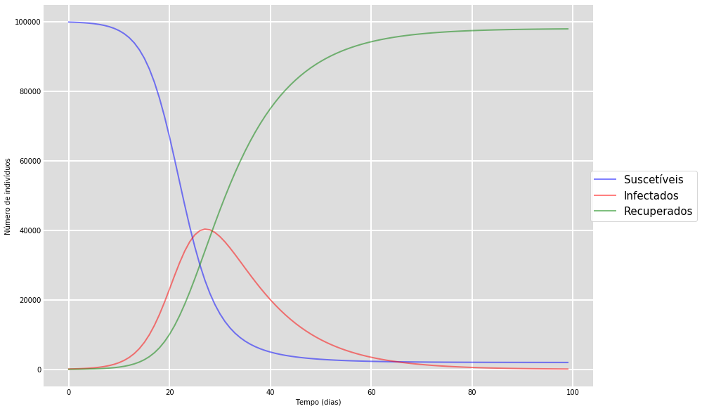

```
 ################################

População:  100000
Recuperados inicialmente:  30
Infectados inicialmente:  200
Taxa de contágio:  0.4
Taxa de recuperação:  0.1

 ################################
```

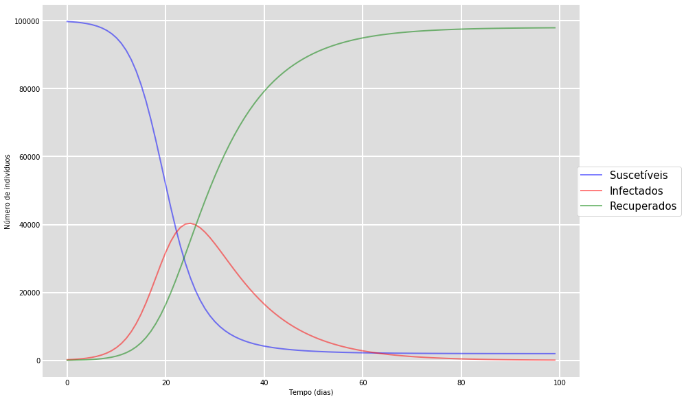

```
 ################################

População:  100000
Recuperados inicialmente:  30
Infectados inicialmente:  50
Taxa de contágio:  0.4
Taxa de recuperação:  0.3

 ################################
```

[15 more figures not shown]

```python
lista_beta = [0.2, 0.4, 0.6]
lista_gamma = [0.1, 0.3, 0.5]

lista_i0 = [50, 100, 200]

for beta in lista_beta:

    for gamma in lista_gamma:

        for i0 in lista_i0:

            print(' ################################ ')
            print(' ')
            print('População: ', N)
            print('Recuperados inicialmente: ', r0)
            print('Infectados inicialmente: ', i0)
            print('Taxa de contágio: ', beta)
            print('Taxa de recuperação: ', gamma)
            print(' ')
            print(' ################################ ')
            print(' ')

            S, I, R = estimativa(beta, gamma, N, i0, r0, t)

            plot(t, S, I, R)
```